# Some Tools for Reproducible Research

Michael Sachs

2016-09-06

# About me

[interactive chart not shown]

Interests:

- Evaluating biomarkers,
- developing and evaluating prediction models,
- statistical software,
- **reproducible research**

# At the lab?

[figure not shown]

# At the computer?

[figure not shown]

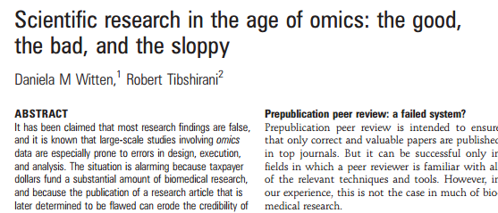

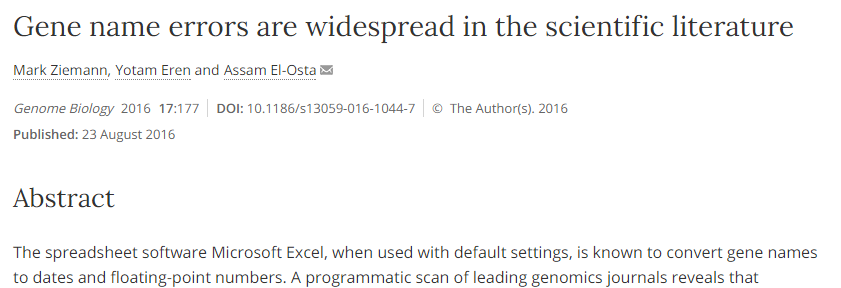

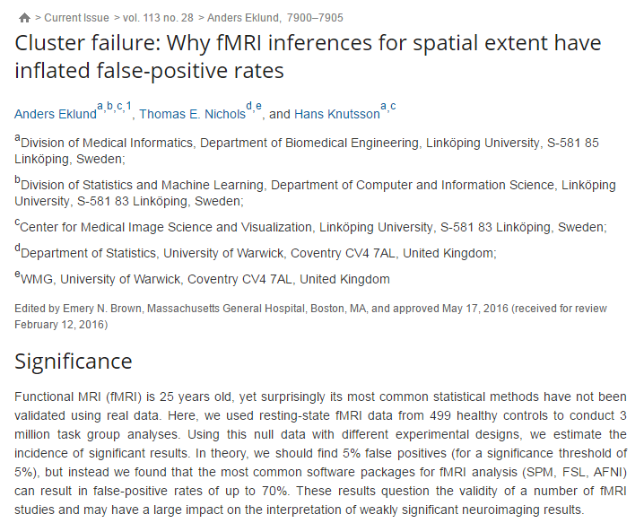

# Scientific Pathway

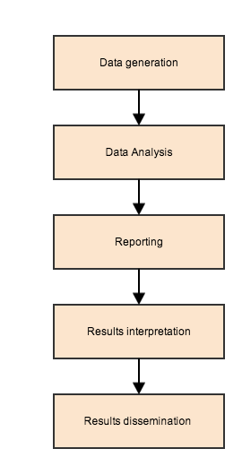

# Scientific Cycle

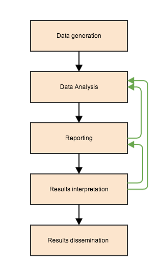

# Where do we fit in?

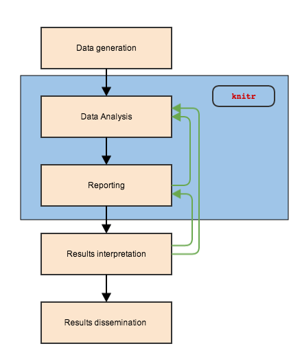

# A framework for risk prediction

### Notation

- $S$ development dataset which includes, for each of $n$ represented individuals,
  - a feature vector $X$,
  - an outcome $Y$,
  - a treatment $Z$, and possibly other variables.
- $S$ is a sample of size $n$ from some distribution
- $f \in \mathcal{F}$ denotes that $f$ is estimated with the class of methods $\mathcal{F}$.
- Let $\phi: \mathcal{D} \times \mathcal{X} \mapsto \mathbb{R}$ denote the statistic that quantifies the performance of the function $f$

# Evaluating performance

- $\phi$ is a function of both $f$ and $S$.
- Interested in estimating $E_\mathcal{P}[\phi_{f^*}(S)]$, for a particular $f^* \in \mathcal{F}$.
- One estimate is $\hat{E}[\phi_f(S)] = \frac{1}{n}\sum_{i=1}^n\phi_f(s_i)$.

However, if the $\mathcal{F}$ involves *interacting with $S$*, then the estimate will be biased.

# Examples of “interacts with $S$”

1. Working on a genomic classifier for binary $Y$:
   - I test it out on $S$, and take a look at the individual-level accuracys $\phi(s_i)$ of a classifier $f(x_i)$
   - For $i$ where $\phi(s_i)$ is poor, manually change the value of $y_i$.
2. Developing a predictor for binary $Y$:
   - Test the association of each $X_j$ with $Y$ using t-test on $S$.
   - Select the 50 most significant
   - Put them all in a regression model and test on $S$
3. Developing predictive signature
   - Split into $S_t$ and $S_h$
   - Build clustering model on $S_t$
   - Test performance on $S_h$
   - Performance isn’t as good as I expected
   - Go back to $S_t$ and try again using a different approach

**Which ones give valid estimates?**

All aspects of $\mathcal{F}$ should be documented and reported

# Tools to make our lives better

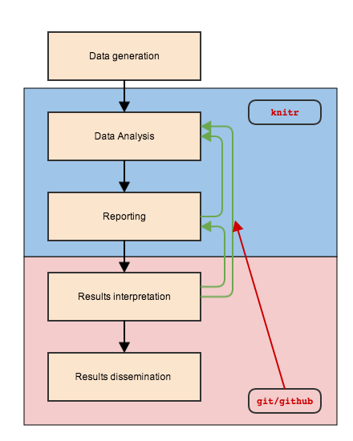

# Data analysis

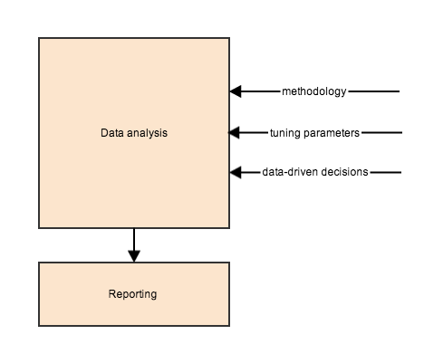

Goals:

- Avoid making arbitrary/data-driven decisions that go undocumented or unreported
- Avoid data manipulations that go undocumented or unreported

# Knitr

### Motivation

- Cut and paste for report production is not a viable method
  - tedious, slow, error-prone
- Incorporate analysis code into text documents
  - `knit` to create results
  - no extra steps to get desired output
  - post-process to get any type of output format
- Literate documents
  - Code creates results to inform report
  - Prose surrounding code informs analysis

# History

- Sweave has been around since 2002
  - Mix R code into Latex docs
  - Problems make it hard to use
  - Most people don’t use Latex
- knitr
  - aimed to solve those problems
  - agnostic about input and output formats
- rmarkdown
  - markdown emerged as a simple but powerful markup language
  - pandoc allows conversion to and from almost any format (even .docx)

# The importance of text

- Text is future-proof
  - No worries about `.doc` $\rightarrow$ `.docx`
  - Cross-platform
  - Useful tools exist to track line-by-line changes in text

# Markdown

Plain-text formatting. Indicate what elements represent, not how they should look. Minimal, yet flexible, html and latex commands are interpreted correctly.

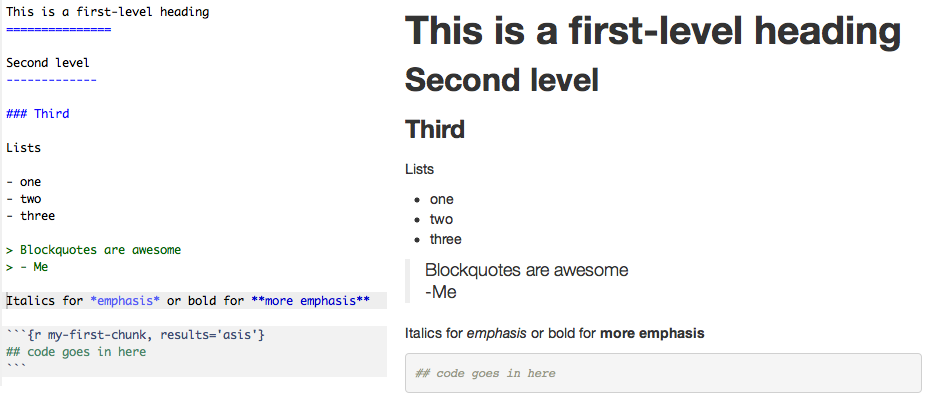

# Contrast with tex

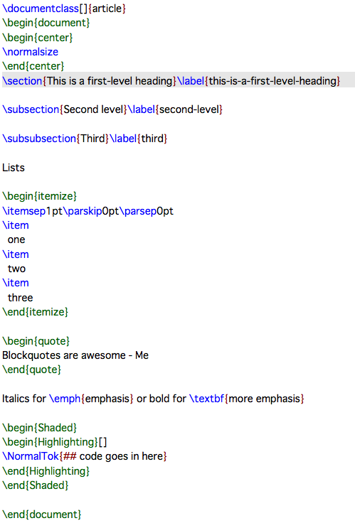

# Markdown specs

- Paragraphs, `# headers, ## subheader, etc`, `> blockquotes`
- Emphasis, `_italics_, *italics*, __bold__, **bold**`
- Images/links: `![name](pathtoimage)`, `[text](link)`
- Lists/ordered lists `- > +`, `1. 2. 3.`
- Latex equations: `$\sum_{i=1}^nX_i/n$` = $\sum_{i=1}^nX_i/n$
- Citations: `[@citekey]`, bibtex, endnote, others supported

# Incorporating code chunks

Three backticks:

````
```{r my-first-chunk, results='asis'}
## code goes in here and gets evaluated
```
````

See http://yihui.name/knitr/options#chunk_options for all available options.

Inline code uses single backticks

# Results, raw output

Raw output using the `mtcars` dataset:

````
```{r mtcars-example}
summary(lm(mpg ~ hp + wt, data = mtcars))
```
````

```
##
## Call:
## lm(formula = mpg ~ hp + wt, data = mtcars)
##
## Residuals:
##    Min     1Q Median     3Q    Max
## -3.941 -1.600 -0.182  1.050  5.854
##
## Coefficients:
##             Estimate Std. Error t value Pr(>|t|)
## (Intercept) 37.22727    1.59879  23.285  < 2e-16 ***
## hp          -0.03177    0.00903  -3.519  0.00145 **
## wt          -3.87783    0.63273  -6.129 1.12e-06 ***
## ---
## Signif. codes:  0 '***' 0.001 '**' 0.01 '*' 0.05 '.' 0.1 ' ' 1
##
## Residual standard error: 2.593 on 29 degrees of freedom
## Multiple R-squared:  0.8268, Adjusted R-squared:  0.8148
## F-statistic: 69.21 on 2 and 29 DF,  p-value: 9.109e-12
```

## Results, a table

Since markdown interprets html, we can use `kable` to generate html tables from `R`

```r
kable(head(mtcars))
```

|  | mpg | cyl | disp | hp | drat | wt | qsec | vs | am | gear | carb |
| --- | --- | --- | --- | --- | --- | --- | --- | --- | --- | --- | --- |
| Mazda RX4 | 21.0 | 6 | 160 | 110 | 3.90 | 2.620 | 16.46 | 0 | 1 | 4 | 4 |
| Mazda RX4 Wag | 21.0 | 6 | 160 | 110 | 3.90 | 2.875 | 17.02 | 0 | 1 | 4 | 4 |
| Datsun 710 | 22.8 | 4 | 108 | 93 | 3.85 | 2.320 | 18.61 | 1 | 1 | 4 | 1 |
| Hornet 4 Drive | 21.4 | 6 | 258 | 110 | 3.08 | 3.215 | 19.44 | 1 | 0 | 3 | 1 |
| Hornet Sportabout | 18.7 | 8 | 360 | 175 | 3.15 | 3.440 | 17.02 | 0 | 0 | 3 | 2 |
| Valiant | 18.1 | 6 | 225 | 105 | 2.76 | 3.460 | 20.22 | 1 | 0 | 3 | 1 |

## Results, a plot

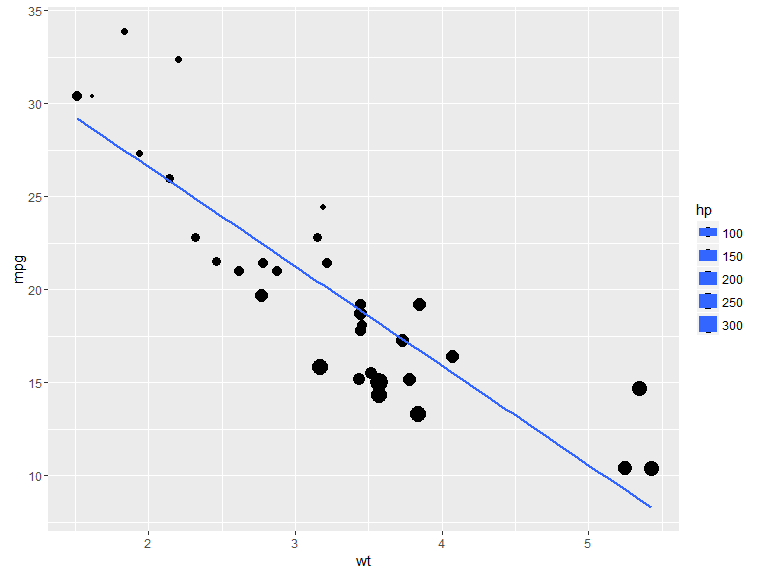

```r
library(ggplot2)
ggplot(mtcars, aes(y = mpg, x = wt, size = hp)) +
  geom_point() + stat_smooth(method = "lm", se = FALSE)
```

# Controlling `R` output

There are at least three functions I’m aware of that will help create output tables.

- `kable` in the `knitr` package
  - simple table generator
  - markdown, html, or tex output
  - few options for customization
- `xtable` in the `xtable` package
  - many options for customization
  - html or tex output
  - clunky interface, some options go to `xtable()` others to `print.xtable()`
- `pandoc.table` in the `pander` package
  - many options for customization

# `kable` example

```r
kable(head(mtcars), digits = 2)
```

|  | mpg | cyl | disp | hp | drat | wt | qsec | vs | am | gear | carb |
| --- | --- | --- | --- | --- | --- | --- | --- | --- | --- | --- | --- |
| Mazda RX4 | 21.0 | 6 | 160 | 110 | 3.90 | 2.62 | 16.46 | 0 | 1 | 4 | 4 |
| Mazda RX4 Wag | 21.0 | 6 | 160 | 110 | 3.90 | 2.88 | 17.02 | 0 | 1 | 4 | 4 |
| Datsun 710 | 22.8 | 4 | 108 | 93 | 3.85 | 2.32 | 18.61 | 1 | 1 | 4 | 1 |
| Hornet 4 Drive | 21.4 | 6 | 258 | 110 | 3.08 | 3.21 | 19.44 | 1 | 0 | 3 | 1 |
| Hornet Sportabout | 18.7 | 8 | 360 | 175 | 3.15 | 3.44 | 17.02 | 0 | 0 | 3 | 2 |
| Valiant | 18.1 | 6 | 225 | 105 | 2.76 | 3.46 | 20.22 | 1 | 0 | 3 | 1 |

# `xtable` example

```r
library(xtable)
print(xtable(head(mtcars)), type = "html")
```

|  | mpg | cyl | disp | hp | drat | wt | qsec | vs | am | gear | carb |
| --- | --- | --- | --- | --- | --- | --- | --- | --- | --- | --- | --- |
| Mazda RX4 | 21.00 | 6.00 | 160.00 | 110.00 | 3.90 | 2.62 | 16.46 | 0.00 | 1.00 | 4.00 | 4.00 |
| Mazda RX4 Wag | 21.00 | 6.00 | 160.00 | 110.00 | 3.90 | 2.88 | 17.02 | 0.00 | 1.00 | 4.00 | 4.00 |
| Datsun 710 | 22.80 | 4.00 | 108.00 | 93.00 | 3.85 | 2.32 | 18.61 | 1.00 | 1.00 | 4.00 | 1.00 |
| Hornet 4 Drive | 21.40 | 6.00 | 258.00 | 110.00 | 3.08 | 3.21 | 19.44 | 1.00 | 0.00 | 3.00 | 1.00 |
| Hornet Sportabout | 18.70 | 8.00 | 360.00 | 175.00 | 3.15 | 3.44 | 17.02 | 0.00 | 0.00 | 3.00 | 2.00 |
| Valiant | 18.10 | 6.00 | 225.00 | 105.00 | 2.76 | 3.46 | 20.22 | 1.00 | 0.00 | 3.00 | 1.00 |

# `pandoc.table` example

```r
library(pander)
pandoc.table(head(mtcars))
```

Table continues below

|  | mpg | cyl | disp | hp | drat | wt | qsec | vs | am |
| --- | --- | --- | --- | --- | --- | --- | --- | --- | --- |
| **Mazda RX4** | 21 | 6 | 160 | 110 | 3.9 | 2.62 | 16.46 | 0 | 1 |
| **Mazda RX4 Wag** | 21 | 6 | 160 | 110 | 3.9 | 2.875 | 17.02 | 0 | 1 |
| **Datsun 710** | 22.8 | 4 | 108 | 93 | 3.85 | 2.32 | 18.61 | 1 | 1 |
| **Hornet 4 Drive** | 21.4 | 6 | 258 | 110 | 3.08 | 3.215 | 19.44 | 1 | 0 |
| **Hornet Sportabout** | 18.7 | 8 | 360 | 175 | 3.15 | 3.44 | 17.02 | 0 | 0 |
| **Valiant** | 18.1 | 6 | 225 | 105 | 2.76 | 3.46 | 20.22 | 1 | 0 |

|  | gear | carb |
| --- | --- | --- |
| **Mazda RX4** | 4 | 4 |
| **Mazda RX4 Wag** | 4 | 4 |
| **Datsun 710** | 4 | 1 |
| **Hornet 4 Drive** | 3 | 1 |
| **Hornet Sportabout** | 3 | 2 |
| **Valiant** | 3 | 1 |

# inline results

Generate every in-text number from code.

`paste` and `sprintf` are my friends.

```r
paste_meansd <- function(x, digits = 2, na.rm = TRUE){
  paste0(round(mean(x, na.rm = na.rm), digits),
         " (", round(sd(x, na.rm = na.rm), digits), ")")
}

## The mean (sd) of a random sample of normals is `r paste_meansd(rnorm(100))`
```

```r
sprint_CI95 <- function(mu, se) {
  lim <- mu + c(-1.96, 1.96) * se
  ### <b>
  sprintf("%.2f (95%% CI: %.2f to %.2f)", mu, lim[1], lim[2])
  ### </b>
}
bfit <- lm(hp ~ disp, mtcars)
## The coefficient estimate is `r sprint_CI95(bfit$coeff[2], sqrt(diag(vcov(bfit)))[2])`
```

The coefficient estimate is 0.44 (95% CI: 0.32 to 0.56).

# Figure options

The important ones:

- `dev`, graphics device. E.g. pdf, png, check out `tikzDevice` if you are creating pdf output:
  - http://bit.ly/114GNdP
- `path` where to save the plot files
- `fig_width`, `fig_height`, `fig_asp` in inches. Can also be set globally.
- `fig_align`, left, right or center

# Other options

# Front matter

Global options set at start of document.

- Document types
  - `pdf_document`, `word_document`, `html_document`
  - `beamer_presentation`, `ioslides_presentation`, `slidy_presentation`
- Other options
  - `bibliography: mybib.bib`
  - Cite with `@paperkey`
  - See http://rmarkdown.rstudio.com/ for complete documentation

```
---
title: "Some Tools for Reproducible Research"
author: "Michael Sachs"
date: "2016-09-06"
output: slidy_presentation
---
```

# Getting started

- Packages:
  - knitr
  - rmarkdown
- Commands:
  - `render('doc.Rmd')` format specified in front matter
  - `render('doc.Rmd', format = 'word_document')`
  - Buttons if you use Rstudio
- Other details:
  - Remember R commands are run sequentially in a session started in the directory where the .Rmd file is saved
  - Use relative paths (e.g. “../Data/file.csv” and not “C:/Home/Data/file.csv”)
  - Never `setwd()`!
- Templates:
  - [Biostat Core Report](https://raw.githubusercontent.com/sachsmc/MCmisc/master/inst/rmarkdown/templates/kiconsult/skeleton/skeleton.Rmd)
  - rticles
  - [Statistics Journals](https://github.com/sachsmc/pandoc-journal-templates)
- Examples:
  - [JSS paper](https://github.com/sachsmc/plotROC-paper/blob/gh-pages/Paper/sachs2015plotROC.Rmd)
  - [JBS paper](https://github.com/sachsmc/signature-tutorial/blob/master/Documents/paper-revised.Rmd)
  - [CCO paper](https://github.com/sachsmc/review-paper-cco/blob/gh-pages/Paper/review-paper-cco.md)

# Limitations

- Markdown is simple
  - Can’t precisely control everything in output
  - How much control do you need?
- R $\rightarrow$ .docx works great
  - R $\nleftarrow$ .docx
  - Incorporating changes and collaborating with clinicians
- Still requires good coding and project organization practices
- Can’t prevent fraud
  - Can: help make open data and open code part of our social norms

# References

1. *The Economist* ‘Trouble at the Lab’ 2013 Oct 19; available at http://go.nature.com/dstij3.
2. Baggerly, Keith A., and Kevin R. Coombes. “Deriving chemosensitivity from cell lines: Forensic bioinformatics and reproducible research in high-throughput biology.” *The Annals of Applied Statistics* (2009): 1309-1334.
3. Witten, Daniela M., and Robert Tibshirani. “Scientific research in the age of omics: the good, the bad, and the sloppy.” *Journal of the American Medical Informatics Association* 20(1) (2013): 125-127.
4. Ziemann, Mark, Yotam Eren, and Assam El-Osta. “Gene name errors are widespread in the scientific literature.” *Genome Biology* 17(1) (2016): 177.
5. Eklund, Anders, Thomas E. Nichols, and Hans Knutsson. “Cluster failure: Why fMRI inferences for spatial extent have inflated false-positive rates.” *Proceedings of the National Academy of Sciences* (2016): 201602413.
6. Leisch, Friedrich. “Sweave: Dynamic generation of statistical reports using literate data analysis.” In *Compstat*, pp. 575-580. Physica-Verlag HD, 2002.
7. Xie, Yihui. *Dynamic Documents with R and knitr*. Vol. 29. CRC Press, 2015.
8. Sachs, Michael C., and Lisa M. McShane. “Issues in developing multivariable molecular signatures for guiding clinical care decisions.” *Journal of Biopharmaceutical Statistics* just-accepted (2016).
9. Rmarkdown, Rstudio. https://rmarkdown.rstudio.com
10. Wilson, Greg, Bryan, Jennifer, Cranston, Karen, et al. “Good Enough Practices in Scientific Computing” (2016). https://arxiv.org/pdf/1609.00037v1.pdf
11. Patil, Prasad, Peng, Roger D., and Jeffrey Leek. “A statistical definition for reproducibility and replicability” (2016), doi: http://dx.doi.org/10.1101/066803.

Source for this talk available at http://github.com/sachsmc/biostat-core-talk-160906